# Enron Submission Free-Response Questions

A critical part of machine learning is making sense of your analysis process and communicating it to others. The questions below will help us understand your decision-making process and allow us to give feedback on your project. Please answer each question; your answers should be about 1-2 paragraphs per question. If you find yourself writing much more than that, take a step back and see if you can simplify your response!

When your evaluator looks at your responses, he or she will use a specific list of rubric items to assess your answers. Here is the link to that rubric: [Link](https://review.udacity.com/#!/rubrics/1767/view). Each question has one or more specific rubric items associated with it, so before you submit an answer, take a look at that part of the rubric. If your response does not meet expectations for all rubric points, you will be asked to revise and resubmit your project. Make sure that your responses are detailed enough that the evaluator will be able to understand the steps you took and your thought processes as you went through the data analysis.

Once you’ve submitted your responses, your coach will take a look and may ask a few more focused follow-up questions on one or more of your answers.  
We can’t wait to see what you’ve put together for this project!

- Question 1
- Question 2
- Question 3
- Question 4
- Question 5
- Question 6

### 1. Summarize for us the goal of this project and how machine learning is useful in trying to accomplish it. As part of your answer, give some background on the dataset and how it can be used to answer the project question. Were there any outliers in the data when you got it, and how did you handle those? [relevant rubric items: “data exploration”, “outlier investigation”]

**R: The goal of the project is to identify POI in Enron scandal using Machine Learning technics. Using this approach, it is possible to, very effectively, evaluate if the data is valid, how is distributed and, finally, using PCA and regression models to predict the data with acceptable performance.**

**The usage of Machine Learning algorithms on this case is particularly important due to the large amount of data dimensions available - the dataset provided has 21 features available from 146 person with only 18 identified as POI - and large variance in many of the features, therefore it is expected that many features has to be used, and probably create new ones to extract information.**

**There are some values that might be consider as outliers, however for most of them, it was choose to keep on the data. Since the goal is to label person as POI, as Katie said on the course, it is expected that most of Enron Insiders was not involved in the scandal, therefore, the outliers would be the POI. This assumption was evaluated and, in fact, the outliers were in many cases associated to POI.**

**The values deleted were the columns loan_advances, deferral_payments, restricted_stock_deferred and director_fees because they have many missing values and the row with index ‘TOTAL’ because it is the sum of all rows therefore not a valid information. The entries for Sanjay Bhatnagar and Robert Belfer were corrected because the values were shifted from the correct columns.**

**All of the evaluations done to get these conclusions are below:**

```python
# import statements
import pickle
from matplotlib import pyplot as plt
import pandas as pd
import numpy as np
%matplotlib inline
```

```python
# Code necessary to convert unix text to windows text
# adapted from https://github.com/udacity/ud120-projects/issues/181

def dos2unix(path):
    """"
    convert dos linefeeds (crlf) to unix (lf)
    usage: dos2unix.py
    """

    original = path
    root = path.split('.')[0]
    destination = root +'_windows.pkl'

    content = ''
    outsize = 0
    with open(original, 'rb') as infile:
        content = infile.read()
    with open(destination, 'wb') as output:
        for line in content.splitlines():
            outsize += len(line) + 1
            output.write(line + str.encode('\n'))
```

```python
### Load the dictionary containing the dataset
dos2unix('final_project_dataset_modified.pkl')
with open("final_project_dataset_windows.pkl", "rb") as data_file:
    data_dict = pickle.load(data_file)
```

```python
# Evaluating the dataset lengh
print("Number of person:", len(data_dict.keys()))

first_key = list(data_dict.keys())[0]
print("Number of features:", len(data_dict[first_key].keys()))

poi_in_data = 0
for key, value in data_dict.items():
    if value['poi']:
        poi_in_data += 1
print("Number of POI already identified:", poi_in_data)
```

```
Number of person: 146
Number of features: 21
Number of POI already identified: 18
```

```python
# Loading the dictionary as dataframe
first_key = list(data_dict.keys())[0]
enron_insiders = pd.DataFrame.from_dict(data_dict, orient='index', columns=data_dict[first_key].keys())
enron_insiders.head()
```

|  | salary | to_messages | deferral_payments | total_payments | loan_advances | bonus | email_address | restricted_stock_deferred | deferred_income | total_stock_value | ... | from_poi_to_this_person | exercised_stock_options | from_messages | other | from_this_person_to_poi | poi | long_term_incentive | shared_receipt_with_poi | restricted_stock | director_fees |
| --- | --- | --- | --- | --- | --- | --- | --- | --- | --- | --- | --- | --- | --- | --- | --- | --- | --- | --- | --- | --- | --- |
| ALLEN PHILLIP K | 201955 | 2902 | 2869717 | 4484442 | NaN | 4175000 | phillip.allen@enron.com | -126027 | -3081055 | 1729541 | ... | 47 | 1729541 | 2195 | 152 | 65 | False | 304805 | 1407 | 126027 | NaN |
| BADUM JAMES P | NaN | NaN | 178980 | 182466 | NaN | NaN | NaN | NaN | NaN | 257817 | ... | NaN | 257817 | NaN | NaN | NaN | False | NaN | NaN | NaN | NaN |
| BANNANTINE JAMES M | 477 | 566 | NaN | 916197 | NaN | NaN | james.bannantine@enron.com | -560222 | -5104 | 5243487 | ... | 39 | 4046157 | 29 | 864523 | 0 | False | NaN | 465 | 1757552 | NaN |
| BAXTER JOHN C | 267102 | NaN | 1295738 | 5634343 | NaN | 1200000 | NaN | NaN | -1386055 | 10623258 | ... | NaN | 6680544 | NaN | 2660303 | NaN | False | 1586055 | NaN | 3942714 | NaN |
| BAY FRANKLIN R | 239671 | NaN | 260455 | 827696 | NaN | 400000 | frank.bay@enron.com | -82782 | -201641 | 63014 | ... | NaN | NaN | NaN | 69 | NaN | False | NaN | NaN | 145796 | NaN |

5 rows × 21 columns

```python
# Check for missing values
print(enron_insiders.isnull().sum())
```

```
salary                       0
to_messages                  0
deferral_payments            0
total_payments               0
loan_advances                0
bonus                        0
email_address                0
restricted_stock_deferred    0
deferred_income              0
total_stock_value            0
expenses                     0
from_poi_to_this_person      0
exercised_stock_options      0
from_messages                0
other                        0
from_this_person_to_poi      0
poi                          0
long_term_incentive          0
shared_receipt_with_poi      0
restricted_stock             0
director_fees                0
dtype: int64
```

**From result above, the dataset has no missing values. It is not consistent with the first peek on the data using .head()**

```python
# Chcek for data types
for col in enron_insiders.columns:
    print(f'{col} datatype: {enron_insiders[col].dtype}')
```

```
salary datatype: object
to_messages datatype: object
deferral_payments datatype: object
total_payments datatype: object
loan_advances datatype: object
bonus datatype: object
email_address datatype: object
restricted_stock_deferred datatype: object
deferred_income datatype: object
total_stock_value datatype: object
expenses datatype: object
from_poi_to_this_person datatype: object
exercised_stock_options datatype: object
from_messages datatype: object
other datatype: object
from_this_person_to_poi datatype: object
poi datatype: bool
long_term_incentive datatype: object
shared_receipt_with_poi datatype: object
restricted_stock datatype: object
director_fees datatype: object
```

**Only columns 'email_address' and 'poi' has the correct datatype. The others, since we should have null values, will be changed to float type in order to use np.NaN.**

```python
# Make a copy of the dataframe
df_enron = enron_insiders.copy()

# Correct the datatypes
for col in df_enron.columns:
    if (col != 'poi') & (col != 'email_address'):
        df_enron[col] = df_enron[col].where(df_enron[col] != 'NaN', np.nan)
        df_enron[col] = df_enron[col].astype('float')
```

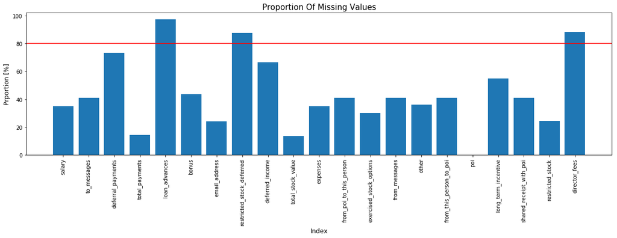

```python
# Check for missing values
null_values = []

for index in df_enron.isnull().sum().index:
    if index == 'email_address':
        null_email = df_enron[df_enron.email_address == "NaN"].shape[0]
        null_values.append((null_email/df_enron.shape[0]*100))
    else:
        null_values.append((df_enron[index].isnull().sum()/df_enron.shape[0])*100)

plt.figure(figsize=(20, 5))
plt.bar(df_enron.isnull().sum().index, null_values)
plt.xticks(nomes, rotation='vertical')
plt.axhline(80, color='red')
plt.xlabel('Index', fontsize=12)
plt.ylabel('Proportion [%]', fontsize=12)
plt.title('Proportion Of Missing Values', fontsize=15);
```

**It is possible to see that some features has more than 80% of missing values. Loan advances, Director fees, Restricted Stock Deferred and Deferral Payments has more than one hundred points without values.**

**In general, series with few data points are not the best features to evaluate when aim to find patterns on the data, because no variation can be gotten from these point.**

**However, since it is expected that most of the persons are not POI, it is interesting to check if the few data that we have are actually from POI. In that case, the columns with few data are actually the best ones to identify POI.**

```python
# Check for missing values from the POI
print('POI with missing values:')
df_enron.query('poi == True').isnull().sum()[['loan_advances', 'deferral_payments', 'restricted_stock_deferred', 'director_fees']]
```

```
POI with missing values:
```

```
loan_advances                17
deferral_payments            13
restricted_stock_deferred    18
director_fees                18
dtype: int64
```

**Since there is 18 POI identified, the results shows that almost every entries identified as POI have no data for the four features evaluated. Therefore, those are probably not good features to include on the model to answer the project question.**

**Another quality issue on the data that may prevent from answer the question is the presence of outliers on the data.**

```python
# Evaluating the financial data on the dataframe, the features with many null values was excluded.
financial_features_edit = ['salary', 'total_payments', 'bonus', 'deferred_income', 'total_stock_value', 'expenses', 'exercised_stock_options',
            'other', 'long_term_incentive', 'restricted_stock']
df_enron[financial_features_edit].describe()
```

|  | salary | total_payments | bonus | deferred_income | total_stock_value | expenses | exercised_stock_options | other | long_term_incentive | restricted_stock |
| --- | --- | --- | --- | --- | --- | --- | --- | --- | --- | --- |
| count | 9.500000e+01 | 1.250000e+02 | 8.200000e+01 | 4.900000e+01 | 1.260000e+02 | 9.500000e+01 | 1.020000e+02 | 9.300000e+01 | 6.600000e+01 | 1.100000e+02 |
| mean | 5.621943e+05 | 5.081526e+06 | 2.374235e+06 | -1.140475e+06 | 6.773957e+06 | 1.087289e+05 | 5.987054e+06 | 9.190650e+05 | 1.470361e+06 | 2.321741e+06 |
| std | 2.716369e+06 | 2.906172e+07 | 1.071333e+07 | 4.025406e+06 | 3.895777e+07 | 5.335348e+05 | 3.106201e+07 | 4.589253e+06 | 5.942759e+06 | 1.251828e+07 |
| min | 4.770000e+02 | 1.480000e+02 | 7.000000e+04 | -2.799289e+07 | -4.409300e+04 | 1.480000e+02 | 3.285000e+03 | 2.000000e+00 | 6.922300e+04 | -2.604490e+06 |
| 25% | 2.118160e+05 | 3.944750e+05 | 4.312500e+05 | -6.948620e+05 | 4.945102e+05 | 2.261400e+04 | 5.278862e+05 | 1.215000e+03 | 2.812500e+05 | 2.540180e+05 |
| 50% | 2.599960e+05 | 1.101393e+06 | 7.693750e+05 | -1.597920e+05 | 1.102872e+06 | 4.695000e+04 | 1.310814e+06 | 5.238200e+04 | 4.420350e+05 | 4.517400e+05 |
| 75% | 3.121170e+05 | 2.093263e+06 | 1.200000e+06 | -3.834600e+04 | 2.949847e+06 | 7.995250e+04 | 2.547724e+06 | 3.620960e+05 | 9.386720e+05 | 1.002370e+06 |
| max | 2.670423e+07 | 3.098866e+08 | 9.734362e+07 | -8.330000e+02 | 4.345095e+08 | 5.235198e+06 | 3.117640e+08 | 4.266759e+07 | 4.852193e+07 | 1.303223e+08 |

**The minimum value for restricted stock and total stock value seems to be wrong since the values on both columns only has positive values.**

```python
# Identify the negative values for these columns
df_enron.query('(restricted_stock < 0) or total_stock_value < 0')
```

|  | salary | to_messages | deferral_payments | total_payments | loan_advances | bonus | email_address | restricted_stock_deferred | deferred_income | total_stock_value | ... | from_poi_to_this_person | exercised_stock_options | from_messages | other | from_this_person_to_poi | poi | long_term_incentive | shared_receipt_with_poi | restricted_stock | director_fees |
| --- | --- | --- | --- | --- | --- | --- | --- | --- | --- | --- | --- | --- | --- | --- | --- | --- | --- | --- | --- | --- | --- |
| BELFER ROBERT | NaN | NaN | -102500.0 | 102500.0 | NaN | NaN | NaN | 44093.0 | NaN | -44093.0 | ... | NaN | 3285.0 | NaN | NaN | NaN | False | NaN | NaN | NaN | 3285.0 |
| BHATNAGAR SANJAY | NaN | 523.0 | NaN | 15456290.0 | NaN | NaN | sanjay.bhatnagar@enron.com | 15456290.0 | NaN | NaN | ... | 0.0 | 2604490.0 | 29.0 | 137864.0 | 1.0 | False | NaN | 463.0 | -2604490.0 | 137864.0 |

2 rows × 21 columns

**Comparing the data with the financial sheet provided, it is concluded that the data were incorrect entred on the dataset. The financial data is shifted for the left and the values on each column is actually from the next column.**

```python
# correct Robert Belfer and Sanjay Bhatnagar entries
financial_features = ['salary', 'bonus', 'long_term_incentive', 'deferred_income', 'deferral_payments', 'loan_advances', 'other',
                      'expenses', 'director_fees', 'total_payments',
                      'exercised_stock_options', 'restricted_stock', 'restricted_stock_deferred', 'total_stock_value']
for pos in range ((len(financial_features)-1), 1, -1):
    df_enron[financial_features[pos]]['BHATNAGAR SANJAY'] = df_enron[financial_features[pos-1]]['BHATNAGAR SANJAY']
    df_enron[financial_features[pos]]['BELFER ROBERT'] = df_enron[financial_features[pos-1]]['BELFER ROBERT']
```

```python
def check_outliers(data, features):
    '''
    Function to evaluate possibles outliers on a dataframe

    input: data - dataframe with the values
           features - list of features that will be evaluated

    output: check_min - list of features to check their lower values
            check_min - list of features to check their upper values
    '''
    check_min = []
    check_max = []
    for feature in features:
        min_outlier_boundary = data[feature].mean() - data[feature].std()
        max_outlier_boundary = data[feature].mean() + data[feature].std()

        if data[feature].min() < min_outlier_boundary:
            print(f'{feature} MINIMUM value worth to check')
            check_min.append(feature)

        if data[feature].max() > max_outlier_boundary:
            print(f'{feature} MAXIMUM value worth to check')
            check_max.append(feature)

    return [check_min, check_max]
```

```python
outlier_min, outlier_max = check_outliers(df_enron, financial_features_edit)
```

```
salary MAXIMUM value worth to check
total_payments MAXIMUM value worth to check
bonus MAXIMUM value worth to check
deferred_income MINIMUM value worth to check
total_stock_value MAXIMUM value worth to check
expenses MAXIMUM value worth to check
exercised_stock_options MAXIMUM value worth to check
other MAXIMUM value worth to check
long_term_incentive MAXIMUM value worth to check
restricted_stock MAXIMUM value worth to check
```

**Clearly, we have a outlier at maximum value**

```python
# Get the entry where the salary is maximum
df_enron[df_enron.salary == df_enron.salary.max()]
```

|  | salary | to_messages | deferral_payments | total_payments | loan_advances | bonus | email_address | restricted_stock_deferred | deferred_income | total_stock_value | ... | from_poi_to_this_person | exercised_stock_options | from_messages | other | from_this_person_to_poi | poi | long_term_incentive | shared_receipt_with_poi | restricted_stock | director_fees |
| --- | --- | --- | --- | --- | --- | --- | --- | --- | --- | --- | --- | --- | --- | --- | --- | --- | --- | --- | --- | --- | --- |
| TOTAL | 26704229.0 | NaN | 32083396.0 | 309886585.0 | 83925000.0 | 97343619.0 | NaN | -7576788.0 | -27992891.0 | 434509511.0 | ... | NaN | 311764000.0 | NaN | 42667589.0 | NaN | False | 48521928.0 | NaN | 130322299.0 | 1398517.0 |

1 rows × 21 columns

**This entry were already discovered when analyzing the data on Udacity Course and it has to be droped until continue the evaluation**

```python
# Remove the Total line of the dataset
df_enron.drop(['TOTAL'], inplace=True)

# Check again for outliers
outlier_min, outlier_max = check_outliers(df_enron, financial_features_edit)
```

```
salary MINIMUM value worth to check
salary MAXIMUM value worth to check
total_payments MAXIMUM value worth to check
bonus MAXIMUM value worth to check
deferred_income MINIMUM value worth to check
total_stock_value MAXIMUM value worth to check
expenses MINIMUM value worth to check
expenses MAXIMUM value worth to check
exercised_stock_options MAXIMUM value worth to check
other MAXIMUM value worth to check
long_term_incentive MAXIMUM value worth to check
restricted_stock MAXIMUM value worth to check
```

**At first, the features with possible lower outliers will be evaluated. This will reduce the numbers of features to check for higher outliers.**

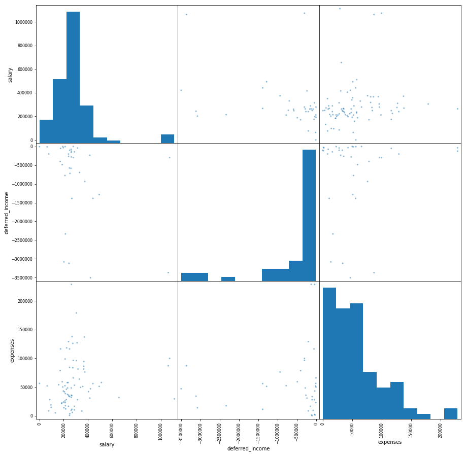

```python
pd.plotting.scatter_matrix(df_enron[outlier_min], figsize=(15, 15));
```

**The data from the features is clearly right skewed - except for deferred income due to the values be negative - however, since we are looking at financial data, this behavior is expected.**

**Evaluating the scatterplots, the is no obvious lower outlier in salary nor expenses. The indication may be due to the higher values effects on the mean and standard deviation. Thefore, the lower outliers only for deferred income will be analized.**

```python
def get_outliers(condition, order='ascending'):
    '''
    Funtion to retunrs the data that meets the defined condition

    input:
        condition - string to define the condition to be met
        order - The sort order
            'ascending' or 'descending'

    output:
        result - series with the data that meets the condition

    '''
    feature = condition.split()[0]

    if order == 'descending':
        result = df_enron.query(condition)[feature].sort_values(ascending=False)
    else:
        result = df_enron.query(condition)[feature].sort_values()

    print(f'From {result.shape[0]} outliers:', end='\n')
    poi, non_poi = identify_poi(condition)

    if len(poi) > 0:
        for person in poi:
            print(f'{person} is POI')

    if len(non_poi) > 0:
        for person in non_poi:
            print(f'{person} is NOT a POI')

def identify_poi(condition):
    '''
    Funtion to identify the POI on a subset of the dataframe defined based on the defined condition

    input:
        data - dataframe
        condition - string to define the row that will be analysed

    output:
        poi - list with POI identified
        non_poi - list with non_POI
    '''
    poi = []
    non_poi = []
    for person in df_enron.query(condition).index:
        if df_enron.loc[person].poi:
            poi.append(person)
        else:
            non_poi.append(person)

    return [poi, non_poi]
```

```python
# Check for the values that are separeated from the histogram
get_outliers('deferred_income < -1500000')
```

```
From 5 outliers:
BELDEN TIMOTHY N is POI
HANNON KEVIN P is POI
RICE KENNETH D is POI
ALLEN PHILLIP K is NOT a POI
FREVERT MARK A is NOT a POI
```

**The data above are the ones further apart on the histogram, however three names are known as POI. Therefore, it seems that, although the values are actually very different from the others, this is something that we need on our data to identify POI.**

```python
# Identify the negative values for restricted stock
get_outliers('restricted_stock > 0.5*10**(7)')
```

```
From 4 outliers:
LAY KENNETH L is POI
SKILLING JEFFREY K is POI
PAI LOU L is NOT a POI
WHITE JR THOMAS E is NOT a POI
```

**Similary to others columns, the values that lays far out the others are associated with POI and it is not intersting to remove them.**

**The values at Salary column was already evaluated during the class and, besides the value for Total entry, it has others outliers, however they are valid points and, furthermore, the value is related to POI.**

```python
get_outliers('salary > 700000', 'descending')
```

```
From 3 outliers:
LAY KENNETH L is POI
SKILLING JEFFREY K is POI
FREVERT MARK A is NOT a POI
```

**Continue with outliers identification, the others features identified having possible outliers will be evaluated with the same approuch as the others.**

```python
# Remove the features already evaluated
outlier_max.remove('salary')
outlier_max.remove('expenses')
outlier_max.remove('restricted_stock')
```

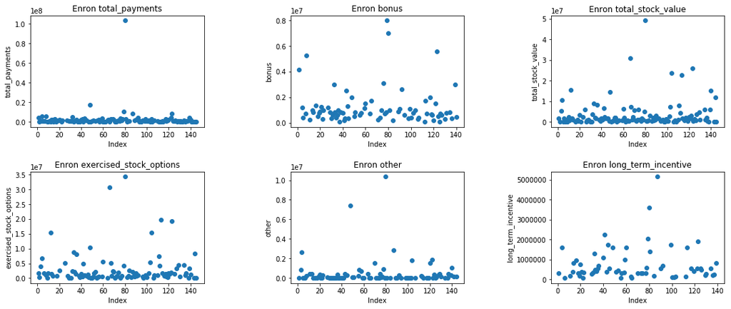

```python
# ploting scatterplots of the featues
x_values = np.arange(1,len(df_enron)+1)
c = 0
fig, axes = plt.subplots(2, 3)
fig.subplots_adjust(top=1.5, right=2.5, hspace=0.4, wspace=0.5)
((ax1, ax2, ax3), (ax4, ax5, ax6)) = axes  # unpack the axes
graph = [ax1, ax2, ax3, ax4, ax5, ax6]
for feature in outlier_max:
    graph[c].scatter(x_values, df_enron[feature])
    graph[c].set_title('Enron '+feature)
    graph[c].set_xlabel('Index')
    graph[c].set_ylabel(feature)
    c += 1
```

```python
get_outliers('total_payments > 0.8*10**8', 'descending')
```

```
From 1 outliers:
LAY KENNETH L is POI
```

```python
get_outliers('total_stock_value > 3*10**7')
```

```
From 2 outliers:
HIRKO JOSEPH is POI
LAY KENNETH L is POI
```

```python
get_outliers('exercised_stock_options > 2.5*10**7')
```

```
From 2 outliers:
HIRKO JOSEPH is POI
LAY KENNETH L is POI
```

```python
get_outliers('other > 0.5*10**7')
```

```
From 2 outliers:
LAY KENNETH L is POI
FREVERT MARK A is NOT a POI
```

### 2. What features did you end up using in your POI identifier, and what selection process did you use to pick them? Did you have to do any scaling? Why or why not? As part of the assignment, you should attempt to engineer your own feature that does not come ready-made in the dataset -- explain what feature you tried to make, and the rationale behind it. (You do not necessarily have to use it in the final analysis, only engineer and test it.) In your feature selection step, if you used an algorithm like a decision tree, please also give the feature importances of the features that you use, and if you used an automated feature selection function like SelectKBest, please report the feature scores and reasons for your choice of parameter values. [relevant rubric items: “create new features”, “intelligently select features”, “properly scale features”]

**R. The feature selection process chosen was the SelectKbest() function from sklearn. It returns the scores for the "k" best features to identify POI, where k is a parameter. The k parameter chosen was k='all', however just for two didactic reasons: analyze how each feature performs when try to identify POI and to evaluate the differences when the new features is added to the data.**

**Prior to any selection, it was required to perform scaling of the features due to high differences on the values. Total Payment feature goes up to hundreds of million and the e-mail messages goes only to a few hundreds. To fairly use them to evaluate importance based on the variation, it is required to put them under comparable size values. MinMaxScaler() function was used.**

**At the end, the 10 features with higher scores were selected to start the POI identifier. This selection took into account that the dimensionalities of the data would be reduced in 50%, however still getting many of the data variance. This number of features will be revaluated when actually creating the classifier. Based on the metrics, it will be decided if there is a chance to reduce more or if it is necessary to increase the number of features.**

**The features evaluated does not include the ones that had almost every value as null, because it was consider that we will be fitting the data to noise. Beside the feature removal, it was added five new features:**

1. from_poi_ratio: fraction of all e-mail messages received by a person that was sent from a POI
2. to_poi_ratio: fraction of all e-mail messages sent by a person that was sent to a POI
3. shared_poi_ratio: fraction of all e-mail messages received by a person that was also sent from a POI
4. bonus_ratio: fraction of the bonus received compared to the salary
5. schemes_citation: number of California schemes that was found on the e-mails text

**The first two features were suggested by Katie on the class. The reason behind is that, if a given person, proportionally, send or receive more e-mails from a POI, this person has better chance of being a POI too.**

**The last three features were made by the student. The third one follows the same approach from the previous two: if a person, proportionally, receives many e-mails that a POI also receives, this person may also be a POI.**

**The fourth feature engineered considered that, prior to the scandal reveal, the POI distributed large amount of bonus [ 3 ] to be cashed in stock to increase their gain while the stock values were still high. The rationale is that the feature would be better predictor than salary and bonus because the higher the bonus-salary ratio is, it would be more likely that the person is a POI.**

**The fifth feature was built aiming to identify citation for Enron's energy schemes in California [ 6 ] to increase their profit, or, actually, reduce their losses. The e-mails on the dataset were scanned and citation for "fat boy", "megawatt laundering", "red congo" and other schemes was counted and the value associated to the e-mail address that sent the message.**

**Not all the features showed good results in better predict the POI. Only to_poi_ratio and shared_poi_ratio was included in the final model as a predictor and the F2 score went up by 4%.**

**All of the evaluations done to get these conclusions are below:**

| GaussianNB() | Precision | Recall | F2 Score |
| --- | --- | --- | --- |
| W/O New Features | 0.368 | 0.366 | 0.365 |
| With New Features | 0.438 | 0.393 | 0.402 |

```python
# Import statments
from sklearn.preprocessing import MinMaxScaler
from sklearn.feature_selection import SelectKBest, f_classif
```

```python
# Delete features with many missing values, e-mail address and POI label
delete_features = ['loan_advances', 'deferral_payments', 'restricted_stock_deferred', 'director_fees', 'email_address', 'poi']

# List of Features that will be evaluated
features_list = [feature for feature in df_enron.columns if feature not in delete_features]
```

```python
# Missing values will be filled with 0 to eliminates its influence
df_enron.fillna(0., inplace=True)

# Create a numpy array required to be input of MinMaxScaler
array_enron = np.array(df_enron[features_list])

# Create Scaler
scaler = MinMaxScaler(feature_range=(0,1))

# Fit data and transform each number
array_enron_scaled = scaler.fit_transform(array_enron)
```

```python
# Create the classifier that will analize all features and return each importance using f classifier
clf = SelectKBest(score_func=f_classif, k='all')

# Fit the data to classifer to return its importance
clf.fit(array_enron_scaled, df_enron.poi);
```

```python
# Create a dataframe with the features and its importance
feature = []
score = []
for pos in range (len(features_list)):
    feature.append(features_list[pos])
    score.append(clf.scores_[pos])

result = pd.DataFrame({'feature': feature, 'score': score})

# Show the results ranked by the most important feature to the least important
result.sort_values('score', ascending=False)
```

|  | feature | score |
| --- | --- | --- |
| 5 | total_stock_value | 23.052394 |
| 8 | exercised_stock_options | 22.867712 |
| 3 | bonus | 21.327890 |
| 0 | salary | 18.861795 |
| 4 | deferred_income | 11.732698 |
| 12 | long_term_incentive | 10.222904 |
| 2 | total_payments | 9.484070 |
| 14 | restricted_stock | 9.094817 |
| 13 | shared_receipt_with_poi | 8.903822 |
| 6 | expenses | 5.689747 |
| 7 | from_poi_to_this_person | 5.446687 |
| 10 | other | 4.278537 |
| 11 | from_this_person_to_poi | 2.470521 |
| 1 | to_messages | 1.751694 |
| 9 | from_messages | 0.158770 |

```python
def get_email_ratio(poi_messages, all_messages):
    '''
    Function to build new columns based on the ratio of messages from a POI to a person and from a person to POI
    Edited from Udacity Class

    output:
        df_edited - dataframe with the aditional columns

    '''

    if all_messages != 0:
        fraction = poi_messages/all_messages
    else:
        fraction = 0.

    return fraction
```

```python
# build the features from_poi_ratio and to_poi_ratio
# features presented on Udacity class

# initiate the list to store the values
from_poi_ratio = []
to_poi_ratio = []

# iterate the dataframe for each person
for person in df_enron.index:

    # get the values to run the built fuction get_email_rate
    from_poi = df_enron.loc[person]['from_poi_to_this_person']
    to_messages = df_enron.loc[person]['to_messages']

    # store the proportion return on the list
    from_poi_ratio.append(get_email_ratio(from_poi, to_messages))

    to_poi = df_enron.loc[person]['from_this_person_to_poi']
    from_messages = df_enron.loc[person]['from_messages']

    to_poi_ratio.append(get_email_ratio(to_poi, from_messages))

# add the features created on enron dataframe
df_enron['from_poi_ratio'] = from_poi_ratio
df_enron['to_poi_ratio'] = to_poi_ratio
```

```python
# build the features shared_poi_ratio and bonus_ratio

shared_poi_ratio = []
bonus_ratio = []

for person in df_enron.index:
    shared_poi = df_enron.loc[person]['shared_receipt_with_poi']
    to_messages = df_enron.loc[person]['to_messages']

    shared_poi_ratio.append(get_email_ratio(shared_poi, to_messages))

    if df_enron.loc[person]['salary'] == 0.:
        bonus_to_salary_proportion = 0.
    else:
        bonus_to_salary_proportion = df_enron.loc[person]['bonus'] / df_enron.loc[person]['salary']

    bonus_ratio.append(bonus_to_salary_proportion)

df_enron['shared_poi_ratio'] = shared_poi_ratio
df_enron['bonus_ratio'] = bonus_ratio
```

```python
# scheme_citation feature was built on the file enron_schemes_search.py
# since there is many e-mails to scan, the output of the algorithm creates a .txt file with the values so it has to be run once

# import the values to a dataframe
with open("../Miniprojetos/ud120-projects/final_project/enron_california_schemes.txt", "rb") as data_file:
    new_feature = pickle.load(data_file)
```

```python
# evaluating the top 10 entires by schemes citation
new_feature.sort_values('schemes_citation', ascending=False)[:10]
```

|  | email_address | schemes_citation |
| --- | --- | --- |
| 97 | ann.schmidt@enron.com | 38 |
| 921 | jeff.dasovich@enron.com | 22 |
| 609 | elizabeth.linnell@enron.com | 20 |
| 908 | jdasovic@enron.com | 20 |
| 1808 | rcarroll@bracepatt.com | 20 |
| 1129 | karen.denne@enron.com | 20 |
| 1463 | mark.palmer@enron.com | 19 |
| 916 | jeannie.mandelker@enron.com | 18 |
| 1993 | seabron.adamson@frontier-economics.com | 18 |
| 305 | cfi1@tca-us.com | 18 |

```python
# check for missing values
new_feature[new_feature.schemes_citation.isnull()]
```

|  | email_address | schemes_citation |
| --- | --- | --- |

```python
# merge new_features dataframe with enron dataframe, however keeping enron index
index = df_enron.index
df_enron = df_enron.merge(new_feature, on='email_address', how='left')
df_enron.set_index(index, inplace=True)
```

```python
# check for missing values
df_enron[df_enron.schemes_citation.isnull()]
```

|  | salary | to_messages | deferral_payments | total_payments | loan_advances | bonus | email_address | restricted_stock_deferred | deferred_income | total_stock_value | ... | poi | long_term_incentive | shared_receipt_with_poi | restricted_stock | director_fees | from_poi_ratio | to_poi_ratio | shared_poi_ratio | bonus_ratio | schemes_citation |
| --- | --- | --- | --- | --- | --- | --- | --- | --- | --- | --- | --- | --- | --- | --- | --- | --- | --- | --- | --- | --- | --- |
| BADUM JAMES P | 0.0 | 0.0 | 178980.0 | 182466.0 | 0.0 | 0.0 | NaN | 0.0 | 0.0 | 257817.0 | ... | False | 0.0 | 0.0 | 0.0 | 0.0 | 0.0 | 0.0 | 0.0 | 0.000000 | NaN |
| BAXTER JOHN C | 267102.0 | 0.0 | 1295738.0 | 5634343.0 | 0.0 | 1200000.0 | NaN | 0.0 | -1386055.0 | 10623258.0 | ... | False | 1586055.0 | 0.0 | 3942714.0 | 0.0 | 0.0 | 0.0 | 0.0 | 4.492666 | NaN |
| BAY FRANKLIN R | 239671.0 | 0.0 | 260455.0 | 827696.0 | 0.0 | 400000.0 | frank.bay@enron.com | -82782.0 | -201641.0 | 63014.0 | ... | False | 0.0 | 0.0 | 145796.0 | 0.0 | 0.0 | 0.0 | 0.0 | 1.668955 | NaN |
| BAZELIDES PHILIP J | 80818.0 | 0.0 | 684694.0 | 860136.0 | 0.0 | 0.0 | NaN | 0.0 | 0.0 | 1599641.0 | ... | False | 93750.0 | 0.0 | 0.0 | 0.0 | 0.0 | 0.0 | 0.0 | 0.000000 | NaN |
| BELFER ROBERT | 0.0 | 0.0 | 0.0 | 3285.0 | -102500.0 | 0.0 | NaN | 0.0 | 0.0 | 44093.0 | ... | False | 0.0 | 0.0 | 3285.0 | 0.0 | 0.0 | 0.0 | 0.0 | 0.000000 | NaN |
| BERBERIAN DAVID | 216582.0 | 0.0 | 0.0 | 228474.0 | 0.0 | 0.0 | david.berberian@enron.com | 0.0 | 0.0 | 2493616.0 | ... | False | 0.0 | 0.0 | 869220.0 | 0.0 | 0.0 | 0.0 | 0.0 | 0.000000 | NaN |
| BLAKE JR. NORMAN P | 0.0 | 0.0 | 0.0 | 1279.0 | 0.0 | 0.0 | NaN | 0.0 | -113784.0 | 0.0 | ... | False | 0.0 | 0.0 | 0.0 | 113784.0 | 0.0 | 0.0 | 0.0 | 0.000000 | NaN |
| BUTTS ROBERT H | 261516.0 | 0.0 | 0.0 | 1271582.0 | 0.0 | 750000.0 | bob.butts@enron.com | 0.0 | -75000.0 | 417619.0 | ... | False | 175000.0 | 0.0 | 417619.0 | 0.0 | 0.0 | 0.0 | 0.0 | 2.867893 | NaN |
| CHAN RONNIE | 0.0 | 0.0 | 0.0 | 0.0 | 0.0 | 0.0 | NaN | -32460.0 | -98784.0 | 0.0 | ... | False | 0.0 | 0.0 | 32460.0 | 98784.0 | 0.0 | 0.0 | 0.0 | 0.000000 | NaN |
| CHRISTODOULOU DIOMEDES | 0.0 | 0.0 | 0.0 | 0.0 | 0.0 | 0.0 | diomedes.christodoulou@enron.com | 0.0 | 0.0 | 6077885.0 | ... | False | 0.0 | 0.0 | 950730.0 | 0.0 | 0.0 | 0.0 | 0.0 | 0.000000 | NaN |
| CLINE KENNETH W | 0.0 | 0.0 | 0.0 | 0.0 | 0.0 | 0.0 | NaN | -472568.0 | 0.0 | 189518.0 | ... | False | 0.0 | 0.0 | 662086.0 | 0.0 | 0.0 | 0.0 | 0.0 | 0.000000 | NaN |
| CUMBERLAND MICHAEL S | 184899.0 | 0.0 | 0.0 | 807956.0 | 0.0 | 325000.0 | NaN | 0.0 | 0.0 | 207940.0 | ... | False | 275000.0 | 0.0 | 207940.0 | 0.0 | 0.0 | 0.0 | 0.0 | 1.757716 | NaN |
| DETMERING TIMOTHY J | 210500.0 | 0.0 | 875307.0 | 1204583.0 | 0.0 | 425000.0 | timothy.detmering@enron.com | -315068.0 | -775241.0 | 2027865.0 | ... | False | 415657.0 | 0.0 | 315068.0 | 0.0 | 0.0 | 0.0 | 0.0 | 2.019002 | NaN |
| DIMICHELE RICHARD G | 262788.0 | 0.0 | 0.0 | 2368151.0 | 0.0 | 1000000.0 | richard.dimichele@enron.com | 0.0 | 0.0 | 8317782.0 | ... | False | 694862.0 | 0.0 | 126027.0 | 0.0 | 0.0 | 0.0 | 0.0 | 3.805349 | NaN |
| DUNCAN JOHN H | 0.0 | 0.0 | 0.0 | 77492.0 | 0.0 | 0.0 | NaN | 0.0 | -25000.0 | 371750.0 | ... | False | 0.0 | 0.0 | 0.0 | 102492.0 | 0.0 | 0.0 | 0.0 | 0.000000 | NaN |
| ECHOLS JOHN B | 182245.0 | 0.0 | 0.0 | 2692324.0 | 0.0 | 200000.0 | john.echols@enron.com | 0.0 | 0.0 | 1008941.0 | ... | False | 2234774.0 | 0.0 | 407503.0 | 0.0 | 0.0 | 0.0 | 0.0 | 1.097424 | NaN |
| ELLIOTT STEVEN | 170941.0 | 0.0 | 0.0 | 211725.0 | 0.0 | 350000.0 | steven.elliott@enron.com | 0.0 | -400729.0 | 6678735.0 | ... | False | 0.0 | 0.0 | 1788391.0 | 0.0 | 0.0 | 0.0 | 0.0 | 2.047490 | NaN |
| FASTOW ANDREW S | 440698.0 | 0.0 | 0.0 | 2424083.0 | 0.0 | 1300000.0 | andrew.fastow@enron.com | 0.0 | -1386055.0 | 1794412.0 | ... | True | 1736055.0 | 0.0 | 1794412.0 | 0.0 | 0.0 | 0.0 | 0.0 | 2.949866 | NaN |
| FUGH JOHN L | 0.0 | 0.0 | 50591.0 | 50591.0 | 0.0 | 0.0 | NaN | 0.0 | 0.0 | 176378.0 | ... | False | 0.0 | 0.0 | 0.0 | 0.0 | 0.0 | 0.0 | 0.0 | 0.000000 | NaN |
| GAHN ROBERT S | 192008.0 | 0.0 | 73122.0 | 900585.0 | 0.0 | 509870.0 | NaN | 0.0 | -1042.0 | 318607.0 | ... | False | 0.0 | 0.0 | 235370.0 | 0.0 | 0.0 | 0.0 | 0.0 | 2.655462 | NaN |
| GATHMANN WILLIAM D | 0.0 | 0.0 | 0.0 | 0.0 | 0.0 | 0.0 | NaN | -72419.0 | 0.0 | 1945360.0 | ... | False | 0.0 | 0.0 | 264013.0 | 0.0 | 0.0 | 0.0 | 0.0 | 0.000000 | NaN |
| GILLIS JOHN | 0.0 | 0.0 | 0.0 | 0.0 | 0.0 | 0.0 | NaN | 0.0 | 0.0 | 85641.0 | ... | False | 0.0 | 0.0 | 75838.0 | 0.0 | 0.0 | 0.0 | 0.0 | 0.000000 | NaN |
| GOLD JOSEPH | 272880.0 | 0.0 | 0.0 | 2146973.0 | 0.0 | 750000.0 | joe.gold@enron.com | 0.0 | 0.0 | 877611.0 | ... | False | 304805.0 | 0.0 | 441096.0 | 0.0 | 0.0 | 0.0 | 0.0 | 2.748461 | NaN |
| GRAMM WENDY L | 0.0 | 0.0 | 0.0 | 119292.0 | 0.0 | 0.0 | NaN | 0.0 | 0.0 | 0.0 | ... | False | 0.0 | 0.0 | 0.0 | 119292.0 | 0.0 | 0.0 | 0.0 | 0.000000 | NaN |
| GRAY RODNEY | 6615.0 | 0.0 | 93585.0 | 1146658.0 | 0.0 | 0.0 | NaN | 0.0 | 0.0 | 0.0 | ... | False | 365625.0 | 0.0 | 0.0 | 0.0 | 0.0 | 0.0 | 0.0 | 0.000000 | NaN |
| HERMANN ROBERT J | 262663.0 | 0.0 | 0.0 | 1297461.0 | 0.0 | 700000.0 | robert.hermann@enron.com | 0.0 | -280000.0 | 668132.0 | ... | False | 150000.0 | 0.0 | 480632.0 | 0.0 | 0.0 | 0.0 | 0.0 | 2.665012 | NaN |
| HIRKO JOSEPH | 0.0 | 0.0 | 10259.0 | 91093.0 | 0.0 | 0.0 | joe.hirko@enron.com | 0.0 | 0.0 | 30766064.0 | ... | True | 0.0 | 0.0 | 0.0 | 0.0 | 0.0 | 0.0 | 0.0 | 0.000000 | NaN |
| JAEDICKE ROBERT | 0.0 | 0.0 | 0.0 | 83750.0 | 0.0 | 0.0 | NaN | -44093.0 | -25000.0 | 431750.0 | ... | False | 0.0 | 0.0 | 44093.0 | 108750.0 | 0.0 | 0.0 | 0.0 | 0.000000 | NaN |
| KISHKILL JOSEPH G | 174246.0 | 0.0 | 0.0 | 704896.0 | 0.0 | 0.0 | joe.kishkill@enron.com | 0.0 | -51042.0 | 1034346.0 | ... | False | 0.0 | 0.0 | 1034346.0 | 0.0 | 0.0 | 0.0 | 0.0 | 0.000000 | NaN |
| KOPPER MICHAEL J | 224305.0 | 0.0 | 0.0 | 2652612.0 | 0.0 | 800000.0 | michael.kopper@enron.com | 0.0 | 0.0 | 985032.0 | ... | True | 602671.0 | 0.0 | 985032.0 | 0.0 | 0.0 | 0.0 | 0.0 | 3.566572 | NaN |
| LEMAISTRE CHARLES | 0.0 | 0.0 | 0.0 | 87492.0 | 0.0 | 0.0 | NaN | 0.0 | -25000.0 | 412878.0 | ... | False | 0.0 | 0.0 | 0.0 | 112492.0 | 0.0 | 0.0 | 0.0 | 0.000000 | NaN |
| LINDHOLM TOD A | 236457.0 | 0.0 | 204075.0 | 875889.0 | 0.0 | 200000.0 | tod.lindholm@enron.com | 0.0 | 0.0 | 3064208.0 | ... | False | 175000.0 | 0.0 | 514847.0 | 0.0 | 0.0 | 0.0 | 0.0 | 0.845820 | NaN |
| LOCKHART EUGENE E | 0.0 | 0.0 | 0.0 | 0.0 | 0.0 | 0.0 | NaN | 0.0 | 0.0 | 0.0 | ... | False | 0.0 | 0.0 | 0.0 | 0.0 | 0.0 | 0.0 | 0.0 | 0.000000 | NaN |
| LOWRY CHARLES P | 0.0 | 0.0 | 0.0 | 0.0 | 0.0 | 0.0 | NaN | -153686.0 | 0.0 | 372205.0 | ... | False | 0.0 | 0.0 | 153686.0 | 0.0 | 0.0 | 0.0 | 0.0 | 0.000000 | NaN |
| MENDELSOHN JOHN | 0.0 | 0.0 | 0.0 | 148.0 | 0.0 | 0.0 | NaN | 0.0 | -103750.0 | 0.0 | ... | False | 0.0 | 0.0 | 0.0 | 103750.0 | 0.0 | 0.0 | 0.0 | 0.000000 | NaN |
| MEYER JEROME J | 0.0 | 0.0 | 0.0 | 2151.0 | 0.0 | 0.0 | NaN | 0.0 | -38346.0 | 0.0 | ... | False | 0.0 | 0.0 | 0.0 | 38346.0 | 0.0 | 0.0 | 0.0 | 0.000000 | NaN |
| MORDAUNT KRISTINA M | 267093.0 | 0.0 | 0.0 | 628522.0 | 0.0 | 325000.0 | kristina.mordaunt@enron.com | 0.0 | 0.0 | 208510.0 | ... | False | 0.0 | 0.0 | 208510.0 | 0.0 | 0.0 | 0.0 | 0.0 | 1.216805 | NaN |
| NOLES JAMES L | 0.0 | 0.0 | 774401.0 | 774401.0 | 0.0 | 0.0 | NaN | -94556.0 | 0.0 | 368705.0 | ... | False | 0.0 | 0.0 | 463261.0 | 0.0 | 0.0 | 0.0 | 0.0 | 0.000000 | NaN |
| OVERDYKE JR JERE C | 94941.0 | 0.0 | 0.0 | 249787.0 | 0.0 | 0.0 | jere.overdyke@enron.com | 0.0 | 0.0 | 7307594.0 | ... | False | 135836.0 | 0.0 | 2041016.0 | 0.0 | 0.0 | 0.0 | 0.0 | 0.000000 | NaN |
| PAI LOU L | 261879.0 | 0.0 | 0.0 | 3123383.0 | 0.0 | 1000000.0 | lou.pai@enron.com | 0.0 | 0.0 | 23817930.0 | ... | False | 0.0 | 0.0 | 8453763.0 | 0.0 | 0.0 | 0.0 | 0.0 | 3.818557 | NaN |
| PEREIRA PAULO V. FERRAZ | 0.0 | 0.0 | 0.0 | 27942.0 | 0.0 | 0.0 | NaN | 0.0 | -101250.0 | 0.0 | ... | False | 0.0 | 0.0 | 0.0 | 101250.0 | 0.0 | 0.0 | 0.0 | 0.000000 | NaN |
| PRENTICE JAMES | 0.0 | 0.0 | 564348.0 | 564348.0 | 0.0 | 0.0 | james.prentice@enron.com | 0.0 | 0.0 | 1095040.0 | ... | False | 0.0 | 0.0 | 208809.0 | 0.0 | 0.0 | 0.0 | 0.0 | 0.000000 | NaN |
| REYNOLDS LAWRENCE | 76399.0 | 0.0 | 51365.0 | 394475.0 | 0.0 | 100000.0 | NaN | -140264.0 | -200000.0 | 4221891.0 | ... | False | 156250.0 | 0.0 | 201483.0 | 0.0 | 0.0 | 0.0 | 0.0 | 1.308918 | NaN |
| SAVAGE FRANK | 0.0 | 0.0 | 0.0 | 3750.0 | 0.0 | 0.0 | NaN | 0.0 | -121284.0 | 0.0 | ... | False | 0.0 | 0.0 | 0.0 | 125034.0 | 0.0 | 0.0 | 0.0 | 0.000000 | NaN |
| SCRIMSHAW MATTHEW | 0.0 | 0.0 | 0.0 | 0.0 | 0.0 | 0.0 | matthew.scrimshaw@enron.com | 0.0 | 0.0 | 759557.0 | ... | False | 0.0 | 0.0 | 0.0 | 0.0 | 0.0 | 0.0 | 0.0 | 0.000000 | NaN |
| STABLER FRANK | 239502.0 | 0.0 | 0.0 | 1112087.0 | 0.0 | 500000.0 | frank.stabler@enron.com | 0.0 | 0.0 | 511734.0 | ... | False | 0.0 | 0.0 | 511734.0 | 0.0 | 0.0 | 0.0 | 0.0 | 2.087665 | NaN |
| SULLIVAN-SHAKLOVITZ COLLEEN | 162779.0 | 0.0 | 181993.0 | 999356.0 | 0.0 | 100000.0 | NaN | 0.0 | 0.0 | 1362375.0 | ... | False | 554422.0 | 0.0 | 0.0 | 0.0 | 0.0 | 0.0 | 0.0 | 0.614330 | NaN |
| THE TRAVEL AGENCY IN THE PARK | 0.0 | 0.0 | 0.0 | 362096.0 | 0.0 | 0.0 | NaN | 0.0 | 0.0 | 0.0 | ... | False | 0.0 | 0.0 | 0.0 | 0.0 | 0.0 | 0.0 | 0.0 | 0.000000 | NaN |
| URQUHART JOHN A | 0.0 | 0.0 | 0.0 | 228656.0 | 0.0 | 0.0 | NaN | 0.0 | -36666.0 | 0.0 | ... | False | 0.0 | 0.0 | 0.0 | 36666.0 | 0.0 | 0.0 | 0.0 | 0.000000 | NaN |
| WAKEHAM JOHN | 0.0 | 0.0 | 0.0 | 213071.0 | 0.0 | 0.0 | NaN | 0.0 | 0.0 | 0.0 | ... | False | 0.0 | 0.0 | 0.0 | 109298.0 | 0.0 | 0.0 | 0.0 | 0.000000 | NaN |
| WALTERS GARETH W | 0.0 | 0.0 | 53625.0 | 87410.0 | 0.0 | 0.0 | NaN | 0.0 | 0.0 | 1030329.0 | ... | False | 0.0 | 0.0 | 0.0 | 0.0 | 0.0 | 0.0 | 0.0 | 0.000000 | NaN |
| WESTFAHL RICHARD K | 63744.0 | 0.0 | 0.0 | 762135.0 | 0.0 | 0.0 | dick.westfahl@enron.com | 0.0 | -10800.0 | 384930.0 | ... | False | 256191.0 | 0.0 | 384930.0 | 0.0 | 0.0 | 0.0 | 0.0 | 0.000000 | NaN |
| WHALEY DAVID A | 0.0 | 0.0 | 0.0 | 0.0 | 0.0 | 0.0 | NaN | 0.0 | 0.0 | 98718.0 | ... | False | 0.0 | 0.0 | 0.0 | 0.0 | 0.0 | 0.0 | 0.0 | 0.000000 | NaN |
| WHITE JR THOMAS E | 317543.0 | 0.0 | 0.0 | 1934359.0 | 0.0 | 450000.0 | thomas.white@enron.com | 0.0 | 0.0 | 15144123.0 | ... | False | 0.0 | 0.0 | 13847074.0 | 0.0 | 0.0 | 0.0 | 0.0 | 1.417131 | NaN |
| WINOKUR JR. HERBERT S | 0.0 | 0.0 | 0.0 | 84992.0 | 0.0 | 0.0 | NaN | 0.0 | -25000.0 | 0.0 | ... | False | 0.0 | 0.0 | 0.0 | 108579.0 | 0.0 | 0.0 | 0.0 | 0.000000 | NaN |
| WODRASKA JOHN | 0.0 | 0.0 | 0.0 | 189583.0 | 0.0 | 0.0 | john.wodraska@enron.com | 0.0 | 0.0 | 0.0 | ... | False | 0.0 | 0.0 | 0.0 | 0.0 | 0.0 | 0.0 | 0.0 | 0.000000 | NaN |
| WROBEL BRUCE | 0.0 | 0.0 | 0.0 | 0.0 | 0.0 | 0.0 | NaN | 0.0 | 0.0 | 139130.0 | ... | False | 0.0 | 0.0 | 0.0 | 0.0 | 0.0 | 0.0 | 0.0 | 0.000000 | NaN |
| YEAGER F SCOTT | 158403.0 | 0.0 | 0.0 | 360300.0 | 0.0 | 0.0 | scott.yeager@enron.com | 0.0 | 0.0 | 11884758.0 | ... | True | 0.0 | 0.0 | 3576206.0 | 0.0 | 0.0 | 0.0 | 0.0 | 0.000000 | NaN |
| YEAP SOON | 0.0 | 0.0 | 0.0 | 55097.0 | 0.0 | 0.0 | NaN | 0.0 | 0.0 | 192758.0 | ... | False | 0.0 | 0.0 | 0.0 | 0.0 | 0.0 | 0.0 | 0.0 | 0.000000 | NaN |

59 rows × 26 columns

```python
# missing values will be filled with 0
df_enron.fillna(0., inplace=True)
```

```python
# Delete features with many missing values, e-mail address and POI label
delete_features = ['loan_advances', 'deferral_payments', 'restricted_stock_deferred', 'director_fees', 'email_address', 'poi']

# List of Features that will be evaluated
new_features_list = [feature for feature in df_enron.columns if feature not in delete_features]
```

```python
# Create a numpy array required to be input of MinMaxScaler
new_array_enron = np.array(df_enron[new_features_list])

# Create Scaler
scaler = MinMaxScaler(feature_range=(0,1))

# Fit data and transform each number
new_array_enron_scaled = scaler.fit_transform(new_array_enron)
```

```python
# Create the classifier that will analize all features and return each importance using f classifier
new_clf = SelectKBest(score_func=f_classif, k='all')

# Fit the data to classifer to return its importance
new_clf.fit(new_array_enron_scaled, df_enron.poi);
```

```python
# Create a dataframe with the features and its importance
new_feature = []
new_score = []
for pos in range (len(new_features_list)):
    new_feature.append(new_features_list[pos])
    new_score.append(new_clf.scores_[pos])

new_result = pd.DataFrame({'feature': new_fea, 'new_score': new_score})
```

```python
# Show the new features in compahison with the previous results
feature_scores = result.merge(new_result, on='feature', how='outer').sort_values('new_score', ascending=False)
feature_scores['rank'] = feature_scores.new_score.rank(ascending=False)
feature_scores.set_index('rank')
```

| rank | feature | score | new_score |
| --- | --- | --- | --- |
| 1.0 | total_stock_value | 23.052394 | 23.052394 |
| 2.0 | exercised_stock_options | 22.867712 | 22.867712 |
| 3.0 | bonus | 21.327890 | 21.327890 |
| 4.0 | salary | 18.861795 | 18.861795 |
| 5.0 | to_poi_ratio | NaN | 16.873870 |
| 6.0 | deferred_income | 11.732698 | 11.732698 |
| 7.0 | bonus_ratio | NaN | 11.127883 |
| 8.0 | long_term_incentive | 10.222904 | 10.222904 |
| 9.0 | shared_poi_ratio | NaN | 9.491458 |
| 10.0 | total_payments | 9.484070 | 9.484070 |
| 11.0 | restricted_stock | 9.094817 | 9.094817 |
| 12.0 | shared_receipt_with_poi | 8.903822 | 8.903822 |
| 13.0 | expenses | 5.689747 | 5.689747 |
| 14.0 | from_poi_to_this_person | 5.446687 | 5.446687 |
| 15.0 | other | 4.278537 | 4.278537 |
| 16.0 | from_poi_ratio | NaN | 3.293829 |
| 17.0 | from_this_person_to_poi | 2.470521 | 2.470521 |
| 18.0 | to_messages | 1.751694 | 1.751694 |
| 19.0 | schemes_citation | NaN | 0.208495 |
| 20.0 | from_messages | 0.158770 | 0.158770 |

### 3. What algorithm did you end up using? What other one(s) did you try? How did model performance differ between algorithms? [relevant rubric item: “pick an algorithm”]

**R. To decide which algorithm to predict POI was better, the performance for each one tried was evaluated with tester.py file from the git cloned. Although to use the code with the sklearn version installed, is was necessary minor changes [ 7 ] to iterate though the indices of training and test set from StratifiedShuffleSplit function.**

**The decision for the algorithm was based on precision and recall scores for each model, with more emphasis in the recall metric. The main goal was catch the POI, even if this would misclassify some Non-POI.**

**The best SVM, which initially was consider that would have the better performance, was a polynomial of third degree, C = 10 and gamma = 0.6.

**K-nearest neighbors - n_neighbors=5 - and Adaboost - learning_rate=3 and n_estimator=20 - was the others best model tried. respectively.**

**The algorithm that most correctly classify POI (precision score) is the Naïve Bayes and the best one to identify POI (recall score) is the Adaboost. The last one, however, it is recalling the POI with a trade-off from misclassification. Naïve Bayes has the balance between precision and recall.**

| Algorithm | Precision | Recall | F2 Score |
| --- | --- | --- | --- |
| Naïve Bayes | 0.368 | 0.366 | 0.365 |
| SVC | 0.235 | 0.243 | 0.241 |
| KNN | 0.237 | 0.087 | 0.100 |
| Adaboost | 0.131 | 0.894 | 0.413 |

### 4. What does it mean to tune the parameters of an algorithm, and what can happen if you don’t do this well? How did you tune the parameters of your particular algorithm? What parameters did you tune? (Some algorithms do not have parameters that you need to tune -- if this is the case for the one you picked, identify and briefly explain how you would have done it for the model that was not your final choice or a different model that does utilize parameter tuning, e.g. a decision tree classifier). [relevant rubric items: “discuss parameter tuning”, “tune the algorithm”]

**R. Tune the parameters means build the boundary with a shape that best classify the training points without lose the capacity of be general enough to predict the labels for test points. If the parameters is not tuned well, the model might end up having bias or variance errors. High bias is when the parameters define an under fitted model (high error for training and test data) and high variance is an over fitted model (very low error for training data, but high error for test data).**

**For the algorithm selected, since it was the Naïve Bayes, it was not required to tune parameters. However, it was tried the Support Vector Classification (SVC) and tested for different kernel trick (polynomial, rbf), different values of C, which defines how well the boundary will fit the data (high C, high fit), gamma, defines how the data will influence the boundary (high gamma, high influence of the data, high fit). For the polynomial, it was also tested different degrees, from one, which is a linear model, and 7, which is a high degree and, probably overfitted.**

**These parameters were tuned applying GridSeachCV(). This function receives the model parameters as its own parameters and does a grid search with all the combinations possible fitting the training data and compute the validation score predicting the test data. The training and test split is done internally by the function.**

### 5. What is validation, and what’s a classic mistake you can make if you do it wrong? How did you validate your analysis? [relevant rubric items: “discuss validation”, “validation strategy”]

**R. Validation is the phase where we actually test the performance of the model in predict new data. Once the classifier is made, it has to be fitted to the data, however since it is never known the classification of new data, it wouldn't be possible to evaluate if the data was fitted properly. Therefore, after fit the classifier, it is validated on a new, but known, set of data.**

**One way to perform validation is splitting the data available into two groups called training and test. The training set is the one to use to fit the model or, in order words, let the model learn the patterns. The test group is used to predict a value using the features and compare it with the actual value. This comparison results on validation scores - such as precision and recall – that is used to evaluated the model.**

**The most common error made on the validation process is the usage of the test data to perform training of the model. The effect of the error is the tendency of the model be overfitted, since it already learn the pattern of the test data.**

**On this project, it was not built a different validation process different that the one in tester.py. It was tried, however, since we have few POI, when the training and test data were split, sometimes one of the groups end ups not having both class of labels to run properly.**

**The algorithm on tester.py avoid this scenario with StratifiedShuffleSplit() function. By using it, the function assure that both sets will have the same proportion of class labels. Furthermore, this function also allows to take advantage of the k-fold validation, when the data is splited between training and test several times, always fitting and validating the model. It is very helpful when a small dataset is used since the model is trained and test in all the data.**

### 6. Give at least 2 evaluation metrics and your average performance for each of them. Explain an interpretation of your metrics that says something human-understandable about your algorithm’s performance. [relevant rubric item: “usage of evaluation metrics”]

**R. It was evaluated two metrics for this project: precision and recall.**

**The precision is the ability of the model to correctly classify the points. On the data evaluated, the precision considers all the points that was classified as POI and evaluates how many was actually a POI. It is a metric that evaluate how many times the model hit the target. At average, all the classifiers tried made a fair good job in correctly classify as POI, the precision vary from 0.13 until 0.44.**

**The ability of recognize the classification of the point is called the recall. Bringing this definition to enron data, it is the ability of, given that a person is a POI, the model would label him as a POI. It is a metric that evaluate how well the model is resembling the patterns learned from the training point.**

### Resources

1. https://www.investopedia.com/updates/enron-scandal-summary/
2. http://edition.cnn.com/ALLPOLITICS/time/2002/01/21/accountable.html
3. http://edition.cnn.com/2002/US/01/25/enron.suicide/
4. https://www.bbc.com/portuguese/economia/020128_esp_eronti.shtml
5. https://en.wikipedia.org/wiki/Death_Star_(business)
6. http://www.mresearch.com/pdfs/19.pdf
7. https://stackoverflow.com/questions/53899066/what-could-be-the-reason-for-typeerror-stratifiedshufflesplit-object-is-not
8. https://stackoverflow.com/questions/51459406/apply-standardscaler-in-pipeline-in-scikit-learn-sklearn